# Estatística no R

### Representação gráfica

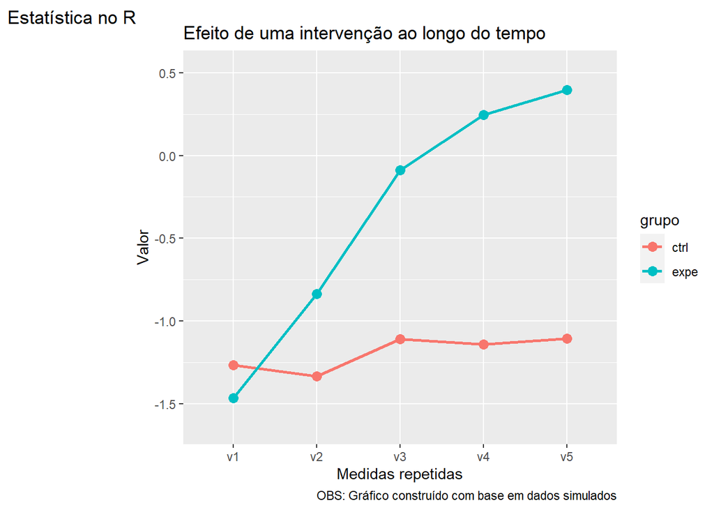

```r
ggplot(data = df_aov2, aes(x = tempo, y = valores, group = grupo, color = grupo)) +
  geom_line(stat = "summary", size = 1) +
  geom_point(stat = "summary", fun.y = "mean", size = 3) +
  labs(title = "Efeito de uma intervenção ao longo do tempo",
       x = "Medidas repetidas",
       y = "Valor",
       caption = 'OBS: Gráfico construído com base em dados simulados',
       tag = "Estatística no R")
```

Relato de resultados: Foram realizadas comparações intragrupo (medidas repetidas) e comparações entre grupos (controle e experimental). Notou-se que houve diferença estatisticamente significativa intragrupo (F<sub>(gl=4,N=100)</sub>=9,489989; p-valor=2.481601e-07) e entre grupos ((F<sub>(gl=1,N=100)</sub>=112.127948; p-valor=6.401131e-18)).

# Exercícios

1. Utilizando o dataframe `dataset`, verifique se há efeito de gênero (sex) em ansiedade (bai_sum) e depressão (bdi_sum). Observe os dados e escolha a estatística mais apropriada para esse tipo de dado.
2. Em relação ao exercício anterior, represente a ansiedade em tabela e a depressão em forma de gráfico.
3. Utilizando o mesmo dataframe, verifique se há diferenças entre países (country) em ansiedade (bai_sum) e depressão (bdi_sum). Observe os dados e escolha a estatística mais apropriada para esse tipo de dado.
4. Em relação ao exercício anterior, represente a ansiedade em tabela e a depressão em forma de gráfico.
5. Execute o código abaixo para gerar o dataframe `df_ex` e realize uma ANOVA de medidas repetidas com esse dataframe. Note que `df_ex` está no **formato amplo**.

```r
df_ex <- data.frame(id = paste("s",1:80,sep = ""),
                    v1 = round(rnorm(n=80, mean = 20, sd = 3),digits = 2),
                    v2 = round(rnorm(n=80, mean = 22, sd = 3),digits = 2),
                    v3 = round(rnorm(n=80, mean = 26, sd = 3),digits = 2),
                    v4 = round(rnorm(n=80, mean = 27, sd = 3),digits = 2),
                    v5 = round(rnorm(n=80, mean = 27, sd = 3),digits = 2))
```